# Lecture 16

## Match Quantifiers

- `*` Matches 0 or more repetitions.
- `+` Matches 1 or more repetitions.
- `?` Matches 0 or 1 repetition (makes it optional).
- `{n}` Matches exactly n repetitions.
- `{n,}` Matches n or more repetitions.
- `{n,m}` Matches between n and m repetitions.

```r
grep(pattern = "x" , c("a", "x", "xx", "xxx", "xxxx"))
```

```
[1] 2 3 4 5
```

```r
grep(pattern = "x*" , c("a", "x", "xx", "xxx", "xxxx"))
```

```
[1] 1 2 3 4 5
```

```r
grep(pattern = "x+" , c("a", "x", "xx", "xxx", "xxxx"))
```

```
[1] 2 3 4 5
```

```r
grep(pattern = "x{2}" , c("a", "x", "xx", "xxx", "xxxx"))
```

```
[1] 3 4 5
```

```r
grep(pattern = "^x{2}$" , c("a", "x", "xx", "xxx", "xxxx"))
```

```
[1] 3
```

## Example (not run)

An application could be web scraping information

```r
library(rvest)

page <- read_html("https://clerk.lacity.gov/contact-us")
page_text <- page %>% html_text()
email_pattern <- "[a-zA-Z0-9._%+-]+@[a-zA-Z0-9.-]+\\.[a-zA-Z]{2,}"

emails <- regmatches(page_text, gregexpr(email_pattern, page_text))[[1]]
print(emails)
```

[1] “Clerk.Media@lacity.org” “Clerk.NBID@lacity.org” “Clerk.CPS@lacity.org” “clerk.cps@lacity.org” “Clerk.NCFunding@lacity.org” “Clerk.Election@lacity.org” [7] “Clerk.RMD@lacity.org”

## A challenge

Here is a website with some data (you might need to copy/paste):

https://raw.githubusercontent.com/fja05680/sp500/refs/heads/master/sp500.csv

How would you extract all of the banks?

## Tidyverse - stringr

[figure not shown]

## stringr notes

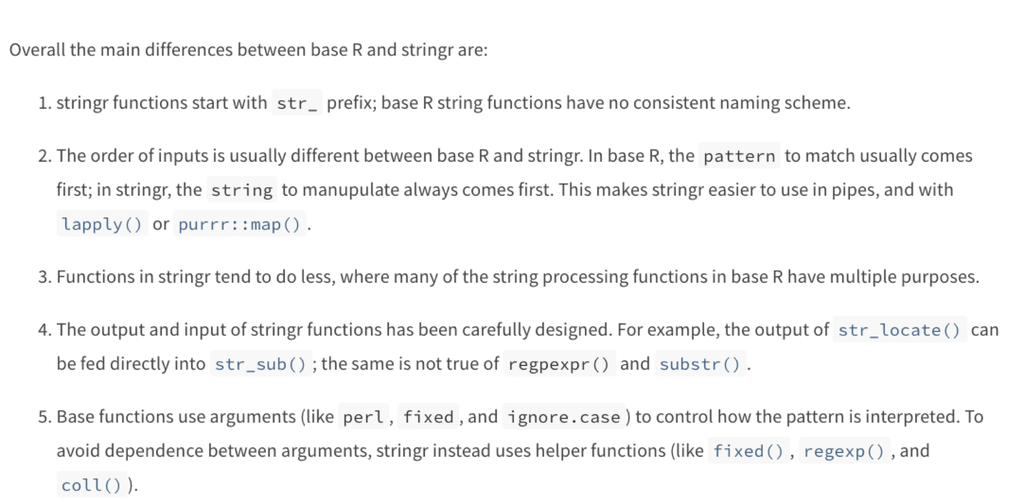

# Break

## Activity Attendance

### Please Greet Your Neighbor(s)

- Practice greeting others in a safe environment. Unitl it becomes natural.
- Reminder: You will not receive credit if it’s only you in the photo, please refrain from photoshopping/editing photos
- Reminder: You need to upload the photo for full credit before the next Tuesday’s lecture. Part or no credit otherwise.
- Please try to greet & meet a different classmate, take a photograph.

# More Programming Functions

## Sampling, Simulation, Repetition

- A necessary skill - the ability to repeatedly perform an action.
  - Sampling
  - Simulation
  - (loops, earlier lecture)

Our alternatives to Repetitive Code and/or unnecessarily long code

## Creating Samples

- Sampling is a kind of repetitive subsetting/extracting from our data.

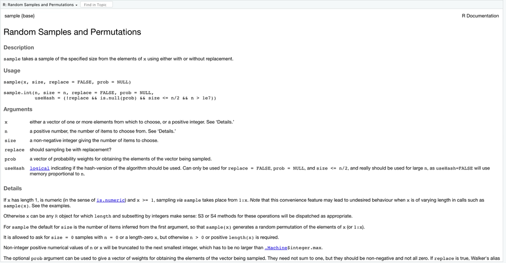

## Basics

```r
## without a seed, implies n = 12 and replace = FALSE and equal probability so it's a permutation
sample(x = 12)

## without a seed, run again, get a different permutation
sample(x = 12)

## set a seed, get a permutation
set.seed(1)
sample(x = 12)
sample(x = 12)

## invoke the exact same seed, get the same permutations
set.seed(1)
sample(x = 12)
sample(x = 12)
```

## Result - Basics

```
 [1] 12 10  6 11  7  2  5  8  4  1  3  9
```

```
 [1]  6  5  2  4 12 10 11  9  1  3  7  8
```

```
 [1]  9  4  7  1  2  5  3  8  6 11 12 10
```

```
 [1]  5 10  6  7  1  9 12 11  8  4  2  3
```

```
 [1]  9  4  7  1  2  5  3  8  6 11 12 10
```

```
 [1]  5 10  6  7  1  9 12 11  8  4  2  3
```

## Other observations

- Do not set a seed unless you must (like it is necessary to generate the exact same values)
- If you set a seed, do not set too many, the results start to become non-random/predictable

```r
## if you don't want a permutation, set size < x
sample(x = 12, size = 6)
```

```
[1]  5  2 10  9  4  7
```

```r
## if you don't want sampling without replacement, set replace = TRUE
sample(x = 12, size = 6, replace = TRUE)
```

```
[1]  1  4  3  6 10 10
```

```r
## we can sample logical vectors too
sample(c(TRUE, FALSE), size = 10, replace = TRUE)
```

```
 [1] FALSE  TRUE FALSE FALSE FALSE FALSE FALSE  TRUE  TRUE FALSE
```

```r
## we can sample character vectors too with different probabilities
fac <- c("Akram", "Maria", "Miles", "Nicolas", "Mahtash", "Vivian", "Samuel",
         "Joshua", "Michael", "Guani", "Linda", "Dave")
sample(fac, size = 3, prob = c(rep(0.10, 8), rep(0.05, 4)))
```

```
[1] "Linda" "Miles" "Maria"
```

## Taking it further via replication

- Here we resample the character vector 10000 times and build a graphic

```r
junk <- replicate(n = 10000, sample(fac, size = 3, prob = c(rep(0.10, 8), rep(0.05, 4))))
table(junk)
```

```
junk
  Akram    Dave   Guani  Joshua   Linda Mahtash   Maria Michael   Miles Nicolas
   2976    1552    1608    2924    1571    2951    3011    1576    2942    2915
 Samuel  Vivian
   2994    2980
```

```r
table(junk) |> prop.table()
```

```
junk
     Akram       Dave      Guani     Joshua      Linda    Mahtash      Maria
0.09920000 0.05173333 0.05360000 0.09746667 0.05236667 0.09836667 0.10036667
   Michael      Miles    Nicolas     Samuel     Vivian
0.05253333 0.09806667 0.09716667 0.09980000 0.09933333
```

```r
## not shown
#barplot(sort(prop.table(table(junk))), col = rainbow(12))
#abline(h = c(0.05, 0.10), col = "black", lwd = 2)
```

## and apply your graphics skills

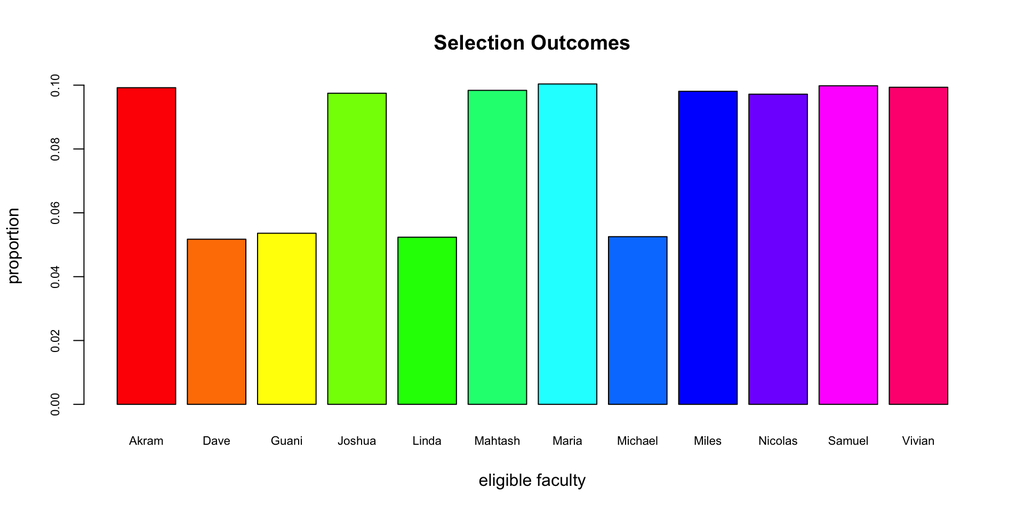

```r
barplot(prop.table(table(junk)), col = rainbow(12), cex.axis = 0.7, cex.names = 0.7)
title(main = "Selection Outcomes", xlab = "eligible faculty", ylab = "proportion")
```

## On Seeds/Pseudorandom numbers

- Why “Pseudo” Random? It means “fake random”.
- The numbers pass all the statistical tests for randomness — they’re spread out evenly, don’t repeat in obvious patterns, and behave like real random numbers — but they came from a formula, not true randomness.
- If you don’t call set.seed(), R grabs something unpredictable from your computer — like the exact millisecond you ran the code — and uses that as the seed. That’s why your results look different each time you run a sample in R:

```r
sample(1:100, 5)
```

```
[1] 21 31 40 96 82
```

```r
sample(1:100, 5)
```

```
[1] 70  1 80 40 60
```

```r
sample(1:100, 5)
```

```
[1] 21 10 89  6 92
```

```r
sample(1:100, 5)
```

```
[1] 82 99 55 91 42
```

## Why Should You Care?

- Video games use pseudorandom numbers to generate maps, outcomes, behaviors
- Cybersecurity uses them to generate encryption keys
- AI and machine learning use them to shuffle training data and initialize models
- Movies use them in visual effects to make simulated rain, fire, and crowds look natural

Randomness in computing is a clever illusion and we see it put to work in the discussion of distributions in Chapter 5 of Braun and Murdoch.

# Probability Distributions

## A little history

- John Graunt (1661) took the step of tabulating data of deaths by age and ordering the ages from lowest to highest and produced the first “life table”.
- While ordering data from low to high seems trivial today, it was not so trivial in the 1600s (imagine data on small scraps of paper).
- And as other scientists begin tabling and graphing their data, this opened the way to examining probability distributions.
- Graunt did not graph his data, but if he had, it would have revealed much about this population quickly.

## Graunt Life Tables

```r
graunt <- data.frame(c(c("0-6", "07-16", "17-26", "27-36", "37-46", "47-56", "57-66", "67-76", "77-86")),
                     c(0.36, 0.24, 0.15, 0.09, 0.06, 0.04, 0.03, 0.02, 0.01),
                     c(1,0.64, 0.40, 0.25, 0.16, 0.10, 0.06, 0.03, 0.01))
names(graunt) <- c("AGE INTERVAL", "Prop. Deaths in Interval", "Prop. Surviving @ Start")
graunt
```

```
  AGE INTERVAL Prop. Deaths in Interval Prop. Surviving @ Start
1          0-6                     0.36                    1.00
2        07-16                     0.24                    0.64
3        17-26                     0.15                    0.40
4        27-36                     0.09                    0.25
5        37-46                     0.06                    0.16
6        47-56                     0.04                    0.10
7        57-66                     0.03                    0.06
8        67-76                     0.02                    0.03
9        77-86                     0.01                    0.01
```

## If Graunt had plotted his data

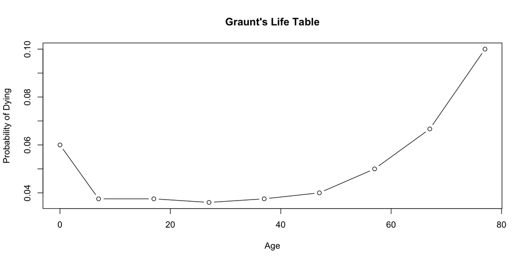

## Some definitions for this section

- Some definitions:
  - If a variable can assume any value between two specified values, it is called a continuous variable
  - Otherwise, it is called a discrete variable.
- A probability distribution is a table or an equation that links each outcome of a statistical experiment with its probability or chance of occurrence. (Consider Graunt’s table - age at death & probability of death)
- Probability distributions can be discrete or continuous too.

## Some Properties

- A discrete probability distribution can be tabled because its outcome can assume exact values (so Graunt made continuous age discrete by categorizing it).
- A continuous variable cannot assume an exact value, that probability is zero. Therefore, continuous probability distributions are not tabled. Instead, formulas or ranges are used to describe probabilities.
- A probability density function is an equation used to describe a continuous probability distribution.

## R’s Probability Distributions

- R’s probability distributions have four separate dedicated functions.
- Each distribution has a root name. For example, the normal is “norm”. The binomial is “binom”
- Also, the distribution functions in R operate in the same manner.
- So if you learn one, you can figure out the others quickly.

## Commonly Seen

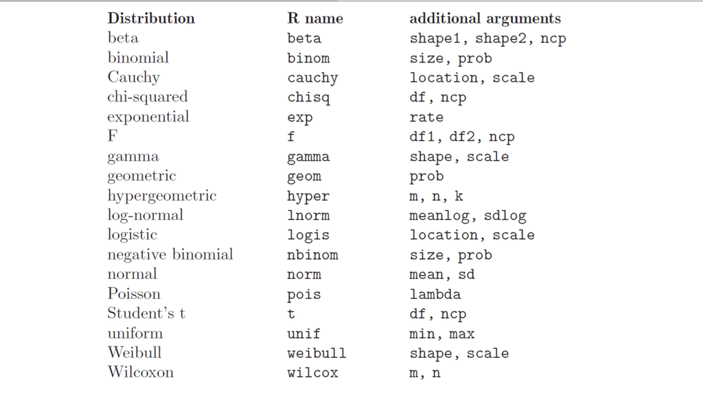

## Distribution Generalities

All of the distributions in R have the following prefixes

- r for “random”, a random variable having the specified distribution. This is the one you’ll use most often. It’s the simulator and will need to know how many you want.
- d for “density”, the probability density function (p. d. f.), answers the question, “how likely is this value”
- p for “probability”, the cumulative distribution function (c. d. f.), answers the question “what proportion falls below this value?”
- q for “quantile”, the inverse c. d. f., the reverse of p given a proportion what value is associated with it.

## Example `rnorm()`

- `rnorm()` has the syntax:

  rnorm(n, mean = 0, sd = 1)
- Where n is a positive integer and is the length of the result.
- `rnorm()` defaults to the standard normal (mean=0 and sd=1)
- We can use it to generate random values from a normal distribution over a given range

## Standard Normal and rnorm

```r
set.seed(1)
x <- rnorm(100) # implies a mean = 0 and sd = 1 standard normal
mean(x)
```

```
[1] 0.1088874
```

```r
sd(x)
```

```
[1] 0.8981994
```

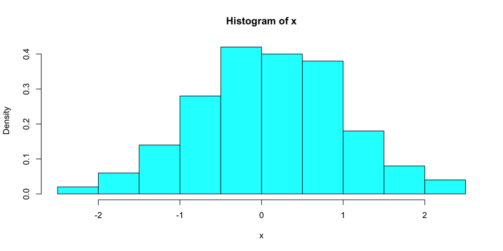

```r
hist(x, freq=FALSE, col = "cyan")
```

## Custom mean and sd

```r
x <- rnorm(100, mean = 100, sd = 15) # like human IQ
mean(x)
```

```
[1] 99.43288
```

```r
sd(x)
```

```
[1] 14.36819
```

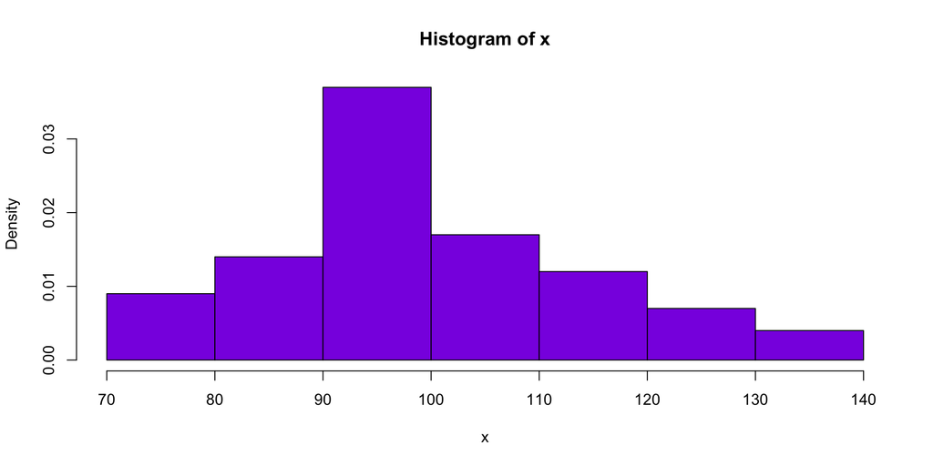

```r
hist(x, freq=FALSE, col = "#8A2BE2")
```

## Some familiar values of Z

These are quantiles of the standard normal

```r
q1 <- c(-2.58, -2.33, -1.96, -1.645, -1.28, -1, -.675, 0)
q2 <- c(.675, 1, 1.28, 1.645, 1.96, 2.33, 2.58 )
```

- pnorm gives us the cumulative probability to that value on the normal curve

```r
round(pnorm(q1),3)
```

```
[1] 0.005 0.010 0.025 0.050 0.100 0.159 0.250 0.500
```

```r
round(pnorm(q2),3)
```

```
[1] 0.750 0.841 0.900 0.950 0.975 0.990 0.995
```

## “Seeing” the area between two quantiles

```r
pnorm(1) - pnorm(-1)
```

```
[1] 0.6826895
```

```r
pnorm(1.645) - pnorm(-1.645)
```

```
[1] 0.9000302
```

```r
pnorm(1.96) - pnorm(-1.96)
```

```
[1] 0.9500042
```

```r
pnorm(2.33) - pnorm(-2.33)
```

```
[1] 0.9801938
```

```r
pnorm(2.58) - pnorm(-2.58)
```

```
[1] 0.99012
```

- pnorm computes probabilities quickly for us

```r
pnorm(120, mean=100, sd= 15) # Human IQ test
```

```
[1] 0.9087888
```

```r
pnorm(770, mean=500, sd= 100) # SAT 25th percentile Princeton
```

```
[1] 0.996533
```

```r
pnorm(640, mean=500, sd= 100) # SAT 25th percentile UCLA
```

```
[1] 0.9192433
```

## Combine viz and prob. functions

```r
par(mfrow = c(2, 1))
x = seq(-4, 4, length = 200)
y = dnorm(x, mean = 0, sd = 1)
plot(x, y, type = "l", main = "pnorm result for Z = -0.675")
x = seq(-4,-0.675, length = 50)
y = dnorm(x, mean = 0, sd = 1)
polygon(c(-4, x ,-0.675),c(0, y, 0),col = "green")
x = seq(-4, 4, length = 200)
y = dnorm(x, mean = 0, sd = 1)
plot(x, y, type = "l", main = "pnorm result for Z = +0.675")
x = seq(-4, 0.675, length = 150)
y = dnorm(x, mean = 0, sd = 1)
polygon(c(-4, x, 0.675),c(0, y, 0),col = "green")
```

## Result

[figure not shown]

## qnorm is the inverse CDF

- give it a cumulative probability, get a quantity (quantile)

```r
qnorm(.95) # given a cumulative probability of .95, what is the value of Z?
```

```
[1] 1.644854
```

```r
qnorm(c(.025, .05, .10, .16, .25, .50, .75, .84, .90, .95, .975, .99))
```

```
 [1] -1.9599640 -1.6448536 -1.2815516 -0.9944579 -0.6744898  0.0000000
 [7]  0.6744898  0.9944579  1.2815516  1.6448536  1.9599640  2.3263479
```

```r
qnorm(0) # not calculable
```

```
[1] -Inf
```

```r
qnorm(1) # not calculable
```

```
[1] Inf
```

```r
## for a different distribution, it gives us the value, in this case
## of the IQ at the 88th percentile
qnorm(.88, mean= 100, sd= 15) ## IQ separating the lower 88% from the upper 12%
```

```
[1] 117.6248
```

```r
## the IQ at the 99.997th percentile
qnorm(.99997, mean= 100, sd= 15) # Einstein's estimated percentile
```

```
[1] 160.1922
```

## dnorm, gives the density of the normal

- How likely is this value?

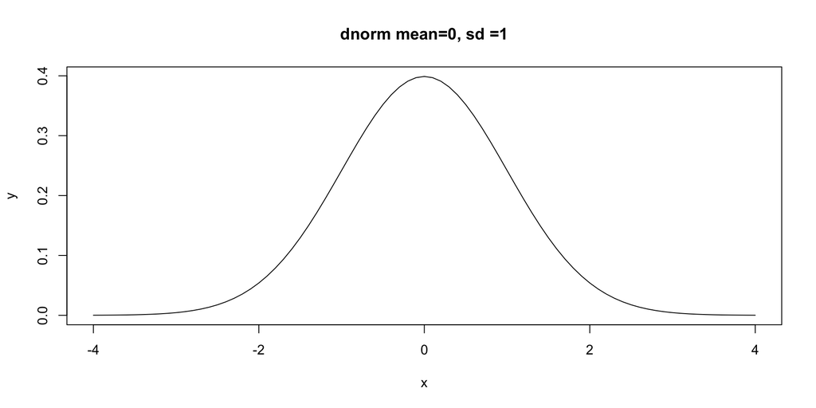

```r
x <- seq(-4,4,by=.1)
y <- dnorm(x)
plot(x,y, type="l", main="dnorm mean=0, sd =1")
```

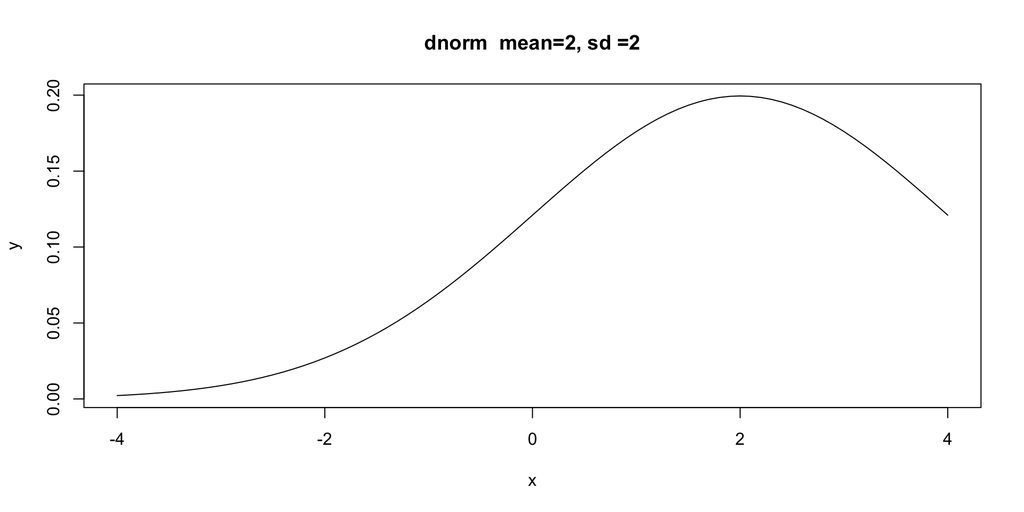

```r
y <- dnorm(x, mean=2, sd=2)
plot(x,y, type="l", main="dnorm  mean=2, sd =2")
```

## with dnorm() plot a normal curve over a distribution

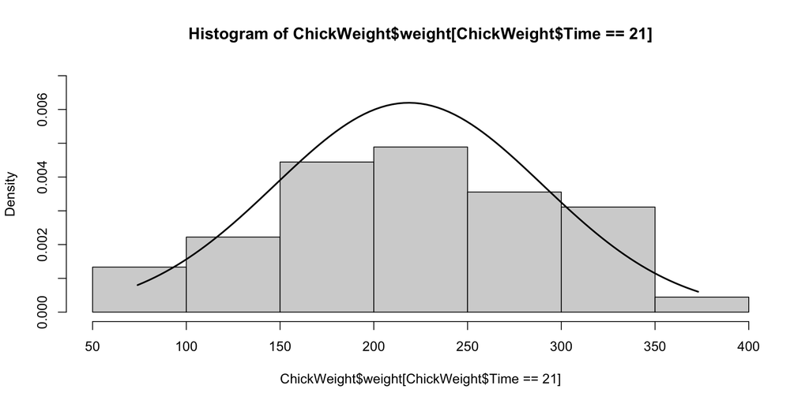

```r
h<-hist(ChickWeight$weight[ChickWeight$Time==21], freq=FALSE, ylim=c(0,.007))
minWt <- min(ChickWeight$weight[ChickWeight$Time==21])
maxWt <- max(ChickWeight$weight[ChickWeight$Time==21])
xfit<-seq(min(minWt),max(maxWt),length=100)
yfit<-dnorm(xfit,mean=mean(ChickWeight$weight[ChickWeight$Time==21]),
            sd=sd(ChickWeight$weight[ChickWeight$Time==21]))
yfit <- (yfit*diff(h$mids[1:2]))/length(ChickWeight$weight[ChickWeight$Time==21])
lines(xfit, yfit, col="black", lwd=2)
```

## how do we know our random normal (rnorm()) is normal?

- We can check with other tools

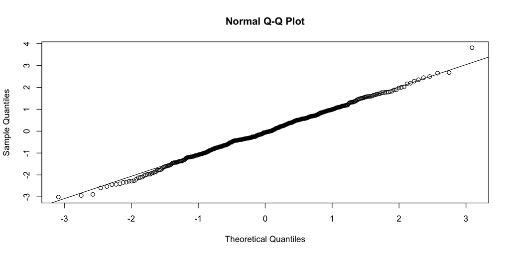

```r
x <- rnorm(500)
qqnorm(x)
qqline(x)
```

With a test perhaps

```r
shapiro.test(x)
```

```
    Shapiro-Wilk normality test

data:  x
W = 0.99774, p-value = 0.7453
```

# Factors

- Factors are variables in R which take on a limited number of different values, typically they are called non-numerical or “categorical” variables.
- We use factors in statistical modeling because non-numerical variables (e.g., ancestry — African, Asian, European, Other) enter into statistical models differently than numerical variables.
- Designating non-numerical data as factors insures that the modeling functions in R will treat these types of variables correctly.

## Underneath a Factor

- Factors in R are stored as a vector of integer values mapped to a corresponding set of character values. The character values are actually what gets displayed.
- This is an efficient way to store character values, because each character value is stored only one time, and the data values are stored as a vector of integers. This requires far fewer computing resources.
- This mechanism behind R’s factors and an AI’s chat window is the same: mapping human-readable text to machine-readable integers using a lookup dictionary.

## Take a look at Factors

```r
print(paste("variable Species in iris is a:", class(iris$Species)))
```

```
[1] "variable Species in iris is a: factor"
```

```r
print(levels(iris$Species))
```

```
[1] "setosa"     "versicolor" "virginica"
```

```r
print(as.numeric(iris$Species))
```

```
  [1] 1 1 1 1 1 1 1 1 1 1 1 1 1 1 1 1 1 1 1 1 1 1 1 1 1 1 1 1 1 1 1 1 1 1 1 1 1
 [38] 1 1 1 1 1 1 1 1 1 1 1 1 1 2 2 2 2 2 2 2 2 2 2 2 2 2 2 2 2 2 2 2 2 2 2 2 2
 [75] 2 2 2 2 2 2 2 2 2 2 2 2 2 2 2 2 2 2 2 2 2 2 2 2 2 2 3 3 3 3 3 3 3 3 3 3 3
[112] 3 3 3 3 3 3 3 3 3 3 3 3 3 3 3 3 3 3 3 3 3 3 3 3 3 3 3 3 3 3 3 3 3 3 3 3 3
[149] 3 3
```

## Bivariate Iris

```r
model1 <- lm(iris$Petal.Length ~ iris$Sepal.Length)
summary(model1)
```

```
Call:
lm(formula = iris$Petal.Length ~ iris$Sepal.Length)

Residuals:
     Min       1Q   Median       3Q      Max
-2.47747 -0.59072 -0.00668  0.60484  2.49512

Coefficients:
                  Estimate Std. Error t value Pr(>|t|)
(Intercept)       -7.10144    0.50666  -14.02   <2e-16 ***
iris$Sepal.Length  1.85843    0.08586   21.65   <2e-16 ***
---
Signif. codes:  0 '***' 0.001 '**' 0.01 '*' 0.05 '.' 0.1 ' ' 1

Residual standard error: 0.8678 on 148 degrees of freedom
Multiple R-squared:   0.76, Adjusted R-squared:  0.7583
F-statistic: 468.6 on 1 and 148 DF,  p-value: < 2.2e-16
```

## Multiple Regression Iris with Factor

```r
model2 <- lm(iris$Petal.Length ~ iris$Sepal.Length + iris$Species)
summary(model2)
```

```
Call:
lm(formula = iris$Petal.Length ~ iris$Sepal.Length + iris$Species)

Residuals:
     Min       1Q   Median       3Q      Max
-0.76390 -0.17875  0.00716  0.17461  0.79954

Coefficients:
                       Estimate Std. Error t value Pr(>|t|)
(Intercept)            -1.70234    0.23013  -7.397 1.01e-11 ***
iris$Sepal.Length       0.63211    0.04527  13.962  < 2e-16 ***
iris$Speciesversicolor  2.21014    0.07047  31.362  < 2e-16 ***
iris$Speciesvirginica   3.09000    0.09123  33.870  < 2e-16 ***
---
Signif. codes:  0 '***' 0.001 '**' 0.01 '*' 0.05 '.' 0.1 ' ' 1

Residual standard error: 0.2826 on 146 degrees of freedom
Multiple R-squared:  0.9749,    Adjusted R-squared:  0.9744
F-statistic:  1890 on 3 and 146 DF,  p-value: < 2.2e-16
```

## When bad things happen

- Factors can be troublesome if one doesn’t understand how their behavior

```r
iris$Sepal_Width_FACTOR <- as.factor(iris$Sepal.Width)
levels(iris$Sepal_Width_FACTOR) # 23 levels representing the unique values
```

```
 [1] "2"   "2.2" "2.3" "2.4" "2.5" "2.6" "2.7" "2.8" "2.9" "3"   "3.1" "3.2"
[13] "3.3" "3.4" "3.5" "3.6" "3.7" "3.8" "3.9" "4"   "4.1" "4.2" "4.4"
```

```r
mean(iris$Sepal_Width_FACTOR) # error
```

```
[1] NA
```

```r
as.numeric(iris$Sepal_Width_FACTOR) |> mean() # some fix it this way, don't
```

```
[1] 10.57333
```

```r
mean(iris$Sepal.Width) # totall different
```

```
[1] 3.057333
```

```r
as.character(iris$Sepal_Width_FACTOR) |> as.numeric() |> mean() # this is clunky but works
```

```
[1] 3.057333
```

## Underneath the factor

```r
iris$Sepal_Width_to_numeric <- as.numeric(iris$Sepal_Width_FACTOR)
iris$Sepal_Width_to_character_numeric <- as.character(iris$Sepal_Width_FACTOR) |> as.numeric()
head(iris[, c(2, 6, 7, 8)], n = 50)
```

```
   Sepal.Width Sepal_Width_FACTOR Sepal_Width_to_numeric
1          3.5                3.5                     15
2          3.0                  3                     10
3          3.2                3.2                     12
4          3.1                3.1                     11
5          3.6                3.6                     16
6          3.9                3.9                     19
7          3.4                3.4                     14
8          3.4                3.4                     14
9          2.9                2.9                      9
10         3.1                3.1                     11
11         3.7                3.7                     17
12         3.4                3.4                     14
13         3.0                  3                     10
14         3.0                  3                     10
```

[output cut: 87 more lines]

## Understanding

- Computers cannot do math on letters. So whether you are estimating a model in R in 101A or interacting with Claude/ChatGPT/etc., the system requires numbers to do its job.
- In R (Factors): If you have a column of survey data with “Low,” “Medium,” and “High,” R assigns integers to represent the values (e.g., 1, 2, 3). It then attaches a dictionary called `levels` to remember that 1 means “Low.” This mapping allows statistical algorithms (like regression) to perform calculations on categories.
- In AI (Tokenization): When you type a sentence into a chat window, the AI chops your words into chunks and assigns each chunk an ID number (e.g., “The” = 464, “cat” = 3432). It aslo uses a dictionary to remember what each number meant. This mapping allows the underlying models to perform linear algebra on your prompt.
- In both cases, integers are used as placeholder for a string to save memory and enable complex math.
- Of course they diverge tremendously: AI chunks words into fragments (e.g., “un” “remark” “able”) and the numeric values assigned to the fragments have no order. The dictionaries AI uses are also massive (e.g., 100,000 times larger than a factor’s levels in R)

## Additional Info regarding factors

- We can create factors using factor() BUT ALSO R can automatically designate variables as factors during certain types of data import or other forms of data reading.
- Both numeric and character variables can be converted into factors, but a factor’s values (known as levels) will always be displayed as character values - for example numbers will have quotes around them because they are being displayed as character